# t1_pandas

[figure not shown]

1 Las Series y DataFrames de Pandas

1.1 Importar librerías

1.2 Estructuras de Datos en Pandas

1.2.1 Series

1.2.2 La clase DataFrame

1.2.3 Traspuesta de un DataFrame

1.3 Acceso a los datos

1.3.1 Selección por etiqueta - `loc`

1.3.2 Selección por posición - `iloc`

1.3.3 Selección mediante filtros

1.4 Actualización de datos de un DataFrame

1.4.1 Modificando valores del DataFrame

1.4.2 Eliminar columnas en un DataFrame

1.4.3 Insertar datos en un DataFrame

1.5 Indices jerárquicos

1.5.1 Referencias

# Las Series y DataFrames de Pandas

La librería Pandas proporciona estructuras de datos de alto nivel que permiten representar series y tablas de datos, así como herramientas diseñadas específicamente para un tratamiento de datos rápido y sencillo.

Pandas es actualmente una de las librerías de alto nivel de Python más utilizadas en las primeras etapas del proceso de análisis de datos, especialmente apropiada en aplicaciones estadísticas.

Se introducen las estructuras principales de Pandas, como son las `Series` y `DataFrames`, así como las operaciones básicas que se pueden realizar con dichas estructuras. Resulta especialmente útil cuando hay que trabajar con datos heterogéneos representados de forma tabular.

Toda la información oficial de la librería se encuentra accesible en el enlace http://pandas.pydata.org.

## Importar librerías

En este capítulo trabajaremos principalmente con las librerías Pandas, NumPy y Matplotlib. Importamos las tres librerías con alias `pd`, `np` y `plt` respectivamente:

```python
import numpy as np
import pandas as pd

import matplotlib.pyplot as plt
%matplotlib inline
```

## Estructuras de Datos en Pandas

Ya vimos que NumPy ofrecía la estructura de datos `ndarray` para representar arrays multidimensionales. En Pandas disponemos de varias estructuras de datos y métodos que nos ayudarán a manipular dichas estructuras de forma sencilla y eficiente. Las dos estructuras de datos principales vienen representadas por las clases *Series* y *DataFrame*, capaces de representar series de datos y datos en forma tabular respectivamente.

### Series

Un objeto del tipo `Series` puede verse como un objeto de tipo array de una dimensión que contiene datos de un cierto tipo y tiene asociado un índice. Este índice es array de etiquetas cuyo tamaño coincide con el tamaño del array de datos.

De aquí en adelante utilizaremos el término *serie* para referirnos a un objeto de tipo `Series`.

A continuación creamos un objeto de tipo `Serie` mediante la función `pd.Series` y una lista de elementos:

```python
s = pd.Series([10, 20, 30, 40, -10])
s
```

```
0    10
1    20
2    30
3    40
4   -10
dtype: int64
```

Como podemos observar, la serie `s` contiene elementos de tipo `int64` (columna de la derecha). Los elementos de la serie están indexados mediante un array de enteros comenzando desde el 0 (columna de la izquierda). Entre las propiedades de los objetos de tipo `Series` tenemos `index` y `values`, que representan el índice y los elementos de la serie:

```python
s.index
```

```
RangeIndex(start=0, stop=5, step=1)
```

```python
s.values
```

```
array([ 10,  20,  30,  40, -10], dtype=int64)
```

Una de las ventajas de trabajar con objetos de tipo `Series`, es que es posible indexar cada elemento de la serie con un valor descriptivo o etiqueta. Por ejemplo, si nuestros datos representan la tasa de natalidad de distintas ciudades españolas, sería interesante usar el nombre de las ciudades cómo etiquetas del índice, en lugar de usar etiquetas de tipo `int`:

```python
nat = pd.Series([10.7, 7.5, 7.1, 17.8, 7.9 ],
               index=['Murcia','Cantabria', 'Galicia', 'Melilla','Canarias' ],
               name = 'Tasa de Natalidad')
```

```python
nat
```

```
Murcia       10.7
Cantabria     7.5
Galicia       7.1
Melilla      17.8
Canarias      7.9
Name: Tasa de Natalidad, dtype: float64
```

El argumento `name` de la función `pd.Series` permite asignar un nombre a la serie creada. Otra de las propiedades de las `Series` es `name`:

```python
nat.name
```

```
'Tasa de Natalidad'
```

En este caso, tenemos dos procedimientos para acceder a los datos de una serie. El primero es mediante la etiqueta del índice y notación de corchetes, como en el caso de las listas o los arrays:

```python
nat['Murcia']
```

```
10.699999999999999
```

El segundo es mediante la etiqueta del índice (siempre que sea un nombre válido en Python) como si fuera una propiedad de la serie:

```python
nat.Murcia
```

```
10.699999999999999
```

Está claro que los datos los podríamos haber representado con un array en lugar de una serie, pero como se puede ver, las series proporcionan mayor claridad en cuanto a los datos que contienen, la forma de acceso, etc. Por ejemplo, es posible preguntar de forma natural si un determinado valor está en el índice:

```python
'Cantabria' in nat.index
```

```
True
```

En cuanto a las operaciones con series, se mantienen muchas de las propiedades vistas para los arrays de NumPy. Por ejemplo, las operaciones aritméticas (`+`, `-` , `*` , `/`) son vectorizadas, manteniéndose el valor del índice de la serie:

```python
nat * 100
```

```
Murcia       1070.0
Cantabria     750.0
Galicia       710.0
Melilla      1780.0
Canarias      790.0
Name: Tasa de Natalidad, dtype: float64
```

Una de las operaciones que se aplican a los arrays de Numpy y que se extienden a las series de Pandas, es la selección de elementos usando arrays de tipo `bool`.

```python
nat[nat < 10]
```

```
Cantabria    7.5
Galicia      7.1
Canarias     7.9
Name: Tasa de Natalidad, dtype: float64
```

El análisis descriptivo de los datos representados mediante una serie se puede realizar usando los métodos `mean` (media), `median` (mediana), `std`(desviación estándar), `min`(mínimo), `max`(máximo) y `quantile`(quantiles) o usando el métodos `describe` de la clase `Series`:

```python
nach = pd.Series([2154, 8184, 10032, 780, 8177],
               index=['Cantabria', 'Canarias',
                      'Galicia', 'Melilla', 'Murcia'],
               name = 'Nacidos Hombres')
```

```python
nach.mean(), nach.median(), nach.std()
```

```
(5865.4, 8177.0, 4114.478679006613)
```

```python
nach.describe()
```

```
count        5.000000
mean      5865.400000
std       4114.478679
min        780.000000
25%       2154.000000
50%       8177.000000
75%       8184.000000
max      10032.000000
Name: Nacidos Hombres, dtype: float64
```

Como complemento a la información proporcionada por el método `describe`, la librería Pandas junto con Matplotlib permiten la creación de los gráficos más comunes en estadística descriptiva. Para crear un diagrama de barras (`bar`):

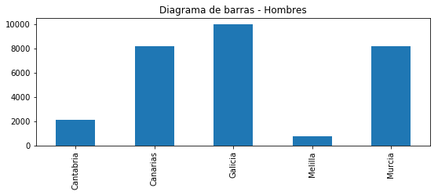

```python
figura, ax1 = plt.subplots(1,  figsize = (9,3))
nach.plot(ax=ax1, kind = 'bar', title = 'Diagrama de barras - Hombres')
```

La gestión de valores duplicados se realiza mediante los métodos `unique` y `value_count` de la clase `Series`. El método `unique` devuelve un array con los valores de la serie sin duplicados. A continuación creamos una serie con valores duplicados:

```python
pos = pd.Series(['Sur', 'Norte',  'Sur', 'Norte'],
               index=['Cádiz', 'Cantabria', 'Melilla',  'Galicia'])
```

```python
pos
```

```
Cádiz          Sur
Cantabria    Norte
Melilla        Sur
Galicia      Norte
dtype: object
```

```python
pos.unique()
```

```
array(['Sur', 'Norte'], dtype=object)
```

Por otro lado, el método `value_counts` devuelve la frecuencia de cada uno de los valores de una serie:

```python
pos.value_counts()
```

```
Norte    2
Sur      2
dtype: int64
```

### La clase DataFrame

La clase `DataFrame` está diseñada para manejar datos representados en forma de tabla, donde tanto las filas como las columnas están indexadas. Los objetos de tipo `DataFrame` pueden verse como una colección ordenada de columnas, cada una de las cuales viene representada por un objeto de tipo `Series`, con su nombre y su índice. Cada columna tiene asociado un tipo de datos y todas las columnas comparten el mísmo índice. En este caso, usaremos el término *dataframe* para referirnos a los objetos de la clase `DataFrame`.

Hay varias formas de crear objetos de tipo `DataFrame` dependiendo de la procedencia de los datos. Podemos usar la función `pd.DataFrame` si los datos se encuentran representados mediante una lista, un diccionario (de listas o de arrays), una `Serie` o incluso otro `DataFrame`. Si los datos en encuentran en un fichero, Pandas proporciona las funciones `pd.read_csv`, `pd.read_excel` o `pd.read_table` para la creación de `DataFrame`.

En el siguiente ejemplo usamos la función `pd.DataFrame` para crear un `DataFrame` a partir de un diccionario:

```python
d = { 'Ciudades' : ['Melilla', 'Canarias', 'Galicia', 'Cantabria', 'Murcia'],
      'Nacidos H': [780, 8184, 10032, 2154, 8177] }
tabla = pd.DataFrame( data = d)
tabla
```

|  | Ciudades | Nacidos H |
| --- | --- | --- |
| 0 | Melilla | 780 |
| 1 | Canarias | 8184 |
| 2 | Galicia | 10032 |
| 3 | Cantabria | 2154 |
| 4 | Murcia | 8177 |

Las claves del diccionario forman el índice de las columnas. El valor de cada una de las claves del diccinario ha de ser una lista o un objeto de tipo `ndarray` de igual longuitud. Al igual que las `Series`, los atributos `index` y `values` representan el índice y los datos del `DataFrame` respectivamente:

```python
tabla.index
```

```
RangeIndex(start=0, stop=5, step=1)
```

```python
tabla.values
```

```
array([['Melilla', 780],
       ['Canarias', 8184],
       ['Galicia', 10032],
       ['Cantabria', 2154],
       ['Murcia', 8177]], dtype=object)
```

A diferencia de las series, que tienen un único índice, los dataframes tienen dos índices. El primero es un índice común para todas las columnas y está asociado a cada una de las filas. El segundo índice contiene un array de etiquetas o nombres de columnas. La propiedad `columns` representa el índice de las columnas:

```python
tabla.columns
```

```
Index(['Ciudades', 'Nacidos H'], dtype='object')
```

La función `pd.DataFrame` admite más argumentos, como por ejemplo los argumentos `index` y `columns` para crear el índice de las filas y columnas del `DataFrame` respectivamente. En el siguiente ejemplo creamos un `DataFrame` con datos acerca de la producción de mantequilla en miles de toneladas de ciertos paises en distintos años (fuente: http://ec.europa.eu/eurostat/web/agriculture/data/main-tables):

```python
tabla3 = pd.DataFrame( data = [ ('Estonia', 8.4, 7.7, 6.7, 'A'),
                                ('Ireland',193.5, 227.76, 221.05, 'B'),
                                ('Greece',1.4,1.6,1.5, 'A'),
                                ('Spain',50.52,58.9,46.72, 'C'),
                                ('France',415.09,423.1,400.52, 'A') ],
                       columns =  ['Desc', '2004', '2005', '2006', 'Tipo'],
                       index = [ 'EE', 'IE', 'EL', 'ES', 'FR'])
tabla3
```

|  | Desc | 2004 | 2005 | 2006 | Tipo |
| --- | --- | --- | --- | --- | --- |
| EE | Estonia | 8.40 | 7.70 | 6.70 | A |
| IE | Ireland | 193.50 | 227.76 | 221.05 | B |
| EL | Greece | 1.40 | 1.60 | 1.50 | A |
| ES | Spain | 50.52 | 58.90 | 46.72 | C |
| FR | France | 415.09 | 423.10 | 400.52 | A |

El método `info` de la clase `DataFrame` muestra información acerca del objeto `DataFrame` (el número de columnas, el número de filas, la cantidad de memoria usada), e información relativa a cada una de las columnas (el nombre de las columnas, su tipo y el número de valores distinto de `NaN`).

```python
tabla3.info()
```

```
<class 'pandas.core.frame.DataFrame'>
Index: 5 entries, EE to FR
Data columns (total 5 columns):
Desc    5 non-null object
2004    5 non-null float64
2005    5 non-null float64
2006    5 non-null float64
Tipo    5 non-null object
dtypes: float64(3), object(2)
memory usage: 240.0+ bytes
```

El método `describe` también se encuentra disponible en la clase `Dataframe`, mostrando los primeros estadísticos, lo que permite hacer un análisis de los datos en cada una de las columnas numéricas.

```python
tabla3.describe()
```

|  | 2004 | 2005 | 2006 |
| --- | --- | --- | --- |
| count | 5.000000 | 5.000000 | 5.000000 |
| mean | 133.782000 | 143.812000 | 135.298000 |
| std | 175.270242 | 180.976401 | 173.191749 |
| min | 1.400000 | 1.600000 | 1.500000 |
| 25% | 8.400000 | 7.700000 | 6.700000 |
| 50% | 50.520000 | 58.900000 | 46.720000 |
| 75% | 193.500000 | 227.760000 | 221.050000 |
| max | 415.090000 | 423.100000 | 400.520000 |

Los datos mostrados son la media (`mean`), la mediana (`median`), la desviación estándar(`std`), el minimo (`min`), el máximo (`max`) y los quantiles (`quantile`).

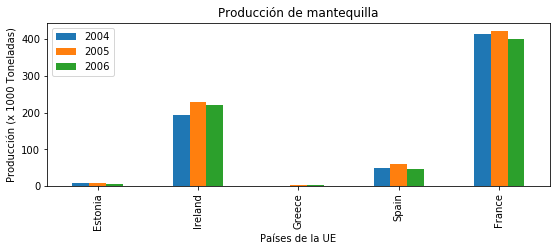

```python
figura, ax1 = plt.subplots(1, figsize = (9,3))

tabla3.plot(ax=ax1, kind = 'bar', title = 'Producción de mantequilla')
ax1.set_xlabel('Países de la UE')
ax1.set_ylabel('Producción (x 1000 Toneladas)')
ax1.set_xticklabels(tabla3.Desc);
```

Al igual que en la clase `Series`, la clase `DataFrame` también dispone de métodos estadísticos (`mean`, `std`, `min`, etc). Estos métodos devuelven un valor solo para aquellas columnas numéricas del objeto `DataFrame`.

```python
tabla3.mean()
```

```
2004    133.782
2005    143.812
2006    135.298
dtype: float64
```

```python
tabla3.std()
```

```
2004    175.270242
2005    180.976401
2006    173.191749
dtype: float64
```

Todas las operaciones estadísticas admiten el argumento `axis`, el cual permite operar bien sobre los datos de las columnas o bien sobre los datos en las filas.

```python
tabla3.sum(axis = 1)
```

```
EE      22.80
IE     642.31
EL       4.50
ES     156.14
FR    1238.71
dtype: float64
```

### Traspuesta de un DataFrame

Una operación muy interesante cuando tratamos con datos representados mediante dataframes, es la de trasponer, es decir, cambiar filas por columnas. Para trasponer un dataframe es necesario utilizar el atributo `T`.

```python
tabla3.T
```

|  | EE | IE | EL | ES | FR |
| --- | --- | --- | --- | --- | --- |
| Desc | Estonia | Ireland | Greece | Spain | France |
| 2004 | 8.4 | 193.5 | 1.4 | 50.52 | 415.09 |
| 2005 | 7.7 | 227.76 | 1.6 | 58.9 | 423.1 |
| 2006 | 6.7 | 221.05 | 1.5 | 46.72 | 400.52 |
| Tipo | A | B | A | C | A |

## Acceso a los datos

Para acceder a las columnas, podemos usar la notación '.' o con la notación empleada en los diccionarios, es decir, notación de corchetes y el nombre de la columna. Como podemos observar, el resultado es un objeto de tipo `Series`:

```python
tabla3.Desc
```

```
EE    Estonia
IE    Ireland
EL     Greece
ES      Spain
FR     France
Name: Desc, dtype: object
```

```python
tabla3['2004']
```

```
EE      8.40
IE    193.50
EL      1.40
ES     50.52
FR    415.09
Name: 2004, dtype: float64
```

Para acceder a partes de un DataFrame, conjunto de filas, conjunto de columnas, etc., se puede utilizar la misma notación empleada para los objetos `ndarray`, pero esa opción es poco eficiente en el caso de `DataFrame`. Una alternativa mas eficiente es utilizar los atributos `loc`, `iloc`.

### Selección por etiqueta - `loc`

Permite recuperar partes del DataFrame indicando el nombre las de filas y columnas que queremos seleccionar, es decir, indicando la/las etiquetas de cada uno de los índices. Presentamos algunos ejemplos que muestran el comportamiento. Para recuperar los datos de los países desde 'IE' hasta 'ES' escribimos los siguiente:

```python
tabla3.loc['IE': 'ES']
```

|  | Desc | 2004 | 2005 | 2006 | Tipo |
| --- | --- | --- | --- | --- | --- |
| IE | Ireland | 193.50 | 227.76 | 221.05 | B |
| EL | Greece | 1.40 | 1.60 | 1.50 | A |
| ES | Spain | 50.52 | 58.90 | 46.72 | C |

Si solo nos interesan la producción en los años 2004 y 2005 de los paises desde 'IE' hasta 'ES' escribimos los siguiente:

```python
res = tabla3.loc['IE':'ES', ['2004', '2005']]
res
```

|  | 2004 | 2005 |
| --- | --- | --- |
| IE | 193.50 | 227.76 |
| EL | 1.40 | 1.60 |
| ES | 50.52 | 58.90 |

Para seleccionar los datos de producción de solo dos paises ('IE' y 'ES') en los años 2004 y 2006, escribimos lo siguiente:

```python
res = tabla3.loc[['IE','ES'], ['2004', '2006']]
res
```

|  | 2004 | 2006 |
| --- | --- | --- |
| IE | 193.50 | 221.05 |
| ES | 50.52 | 46.72 |

Para seleccionar un valor escalar, por ejemplo la producción de mantequilla en el año 2006 en el pais 'IE', escribimos:

```python
tabla3.loc['IE', '2006']
```

```
221.05000000000001
```

### Selección por posición - `iloc`

La propiedad `iloc` permite recuperar partes del `DataFrame` indexando filas y columnas con valores de tipo `int` comenzando desde el 0. Para seleccionar la primera fila del `DataFrame` escribimos lo siguiente:

```python
tabla3.iloc[0]
```

```
Desc    Estonia
2004        8.4
2005        7.7
2006        6.7
Tipo          A
Name: EE, dtype: object
```

El resultado es un objeto de tipo `Series`. El nombre de la serie coincide con el valor del índice de la fila seleccionada. Para recuperar las tres primeras filas y la primera y última columna, escribimos lo siguiente:

```python
tabla3.iloc[:3,[0,-1]]
```

|  | Desc | Tipo |
| --- | --- | --- |
| EE | Estonia | A |
| IE | Ireland | B |
| EL | Greece | A |

```python
tabla3.iloc[1,0]
```

```
'Ireland'
```

### Selección mediante filtros

Otra forma de seleccionar partes de un dataframe es mediante el uso de filtros, de forma similar a cómo se aplicaban en el caso de los arrays de Numpy.

```python
t = tabla3['2004']
t
```

```
EE      8.40
IE    193.50
EL      1.40
ES     50.52
FR    415.09
Name: 2004, dtype: float64
```

```python
t[t < 100]
```

```
EE     8.40
EL     1.40
ES    50.52
Name: 2004, dtype: float64
```

## Actualización de datos de un DataFrame

En muchas ocasiones los datos que se están analizando no continen toda la información que necesitamos para nuestro análisis, o símplemente no están en el formato apropiado. En estos casos, Pandas ofrece la posibilidad de modificar los valores del `DataFrame`, borrar columnas, crear columnas con nuevos valores o incluso columnas cuyos valores se calculan a partir de los valores de otras columnas.

### Modificando valores del DataFrame

Para actualizar los datos de una columna podemos utilizar un valor concreto o un array de valores.

```python
tabla3.Tipo = 'D'
```

```python
tabla3
```

|  | Desc | 2004 | 2005 | 2006 | Tipo |
| --- | --- | --- | --- | --- | --- |
| EE | Estonia | 8.40 | 7.70 | 6.70 | D |
| IE | Ireland | 193.50 | 227.76 | 221.05 | D |
| EL | Greece | 1.40 | 1.60 | 1.50 | D |
| ES | Spain | 50.52 | 58.90 | 46.72 | D |
| FR | France | 415.09 | 423.10 | 400.52 | D |

```python
tabla3.Tipo = ['D', 'D', 'D', 'E', 'F']
```

```python
tabla3
```

|  | Desc | 2004 | 2005 | 2006 | Tipo |
| --- | --- | --- | --- | --- | --- |
| EE | Estonia | 8.40 | 7.70 | 6.70 | D |
| IE | Ireland | 193.50 | 227.76 | 221.05 | D |
| EL | Greece | 1.40 | 1.60 | 1.50 | D |
| ES | Spain | 50.52 | 58.90 | 46.72 | E |
| FR | France | 415.09 | 423.10 | 400.52 | F |

También podemos modificar el valor de una columna aplicando una función de transformación. Por ejemplo, si queremos transformar los valores de la columna `Desc` a mayúsculas, escribimos lo siguiente:

```python
tabla3.Desc = tabla3.Desc.map(lambda x :str.upper(x))
```

```python
tabla3
```

|  | Desc | 2004 | 2005 | 2006 | Tipo |
| --- | --- | --- | --- | --- | --- |
| EE | ESTONIA | 8.40 | 7.70 | 6.70 | D |
| IE | IRELAND | 193.50 | 227.76 | 221.05 | D |
| EL | GREECE | 1.40 | 1.60 | 1.50 | D |
| ES | SPAIN | 50.52 | 58.90 | 46.72 | E |
| FR | FRANCE | 415.09 | 423.10 | 400.52 | F |

La función `map` aplica la función `lambda` a cada uno de los valores de la columna. Si queremos modificar todos los datos de tipo numérico del `DataFrame` de forma que los datos se expresen con un único decimal, usamos la función `applymap` junto con una función `lambda` como se muestra a continuación:

```python
tabla3 = tabla3.applymap(lambda x : round(x,1) if type(x) == float else x)
tabla3
```

|  | Desc | 2004 | 2005 | 2006 | Tipo |
| --- | --- | --- | --- | --- | --- |
| EE | ESTONIA | 8.4 | 7.7 | 6.7 | D |
| IE | IRELAND | 193.5 | 227.8 | 221.1 | D |
| EL | GREECE | 1.4 | 1.6 | 1.5 | D |
| ES | SPAIN | 50.5 | 58.9 | 46.7 | E |
| FR | FRANCE | 415.1 | 423.1 | 400.5 | F |

### Eliminar columnas en un DataFrame

El método `pop` de la clase `DataFrame` elimina la columna especificada y devuelve dicha columna en un objeto de tipo `Series`. Este método modifica el `DataFrame`. Por otro lado, el método `drop` permite borrar tanto filas como columnas, con la diferencia de que no devuelve los elementos borrados y no modifica el Dataframe, sino que devuelve una copia:

```python
columna_tipo = tabla3.pop('Tipo')
columna_tipo
```

```
EE    D
IE    D
EL    D
ES    E
FR    F
Name: Tipo, dtype: object
```

```python
type(columna_tipo)
```

```
pandas.core.series.Series
```

```python
tabla3
```

|  | Desc | 2004 | 2005 | 2006 |
| --- | --- | --- | --- | --- |
| EE | ESTONIA | 8.4 | 7.7 | 6.7 |
| IE | IRELAND | 193.5 | 227.8 | 221.1 |
| EL | GREECE | 1.4 | 1.6 | 1.5 |
| ES | SPAIN | 50.5 | 58.9 | 46.7 |
| FR | FRANCE | 415.1 | 423.1 | 400.5 |

También es posible utilizar el método `drop` para eliminar tanto filas como columnas. Para borrar columnas con `drop`, es necesario indicarlo mediante el argumento `axis` del método:

```python
nuevo_df = tabla3.drop(['IE','FR'])
nuevo_df
```

|  | Desc | 2004 | 2005 | 2006 |
| --- | --- | --- | --- | --- |
| EE | ESTONIA | 8.4 | 7.7 | 6.7 |
| EL | GREECE | 1.4 | 1.6 | 1.5 |
| ES | SPAIN | 50.5 | 58.9 | 46.7 |

```python
tabla3
```

|  | Desc | 2004 | 2005 | 2006 |
| --- | --- | --- | --- | --- |
| EE | ESTONIA | 8.4 | 7.7 | 6.7 |
| IE | IRELAND | 193.5 | 227.8 | 221.1 |
| EL | GREECE | 1.4 | 1.6 | 1.5 |
| ES | SPAIN | 50.5 | 58.9 | 46.7 |
| FR | FRANCE | 415.1 | 423.1 | 400.5 |

```python
tabla3.columns
```

```
Index(['Desc', '2004', '2005', '2006'], dtype='object')
```

```python
tabla3.drop(['Desc', '2006'], axis = 1)
```

|  | 2004 | 2005 |
| --- | --- | --- |
| EE | 8.4 | 7.7 |
| IE | 193.5 | 227.8 |
| EL | 1.4 | 1.6 |
| ES | 50.5 | 58.9 |
| FR | 415.1 | 423.1 |

```python
tabla3
```

|  | Desc | 2004 | 2005 | 2006 |
| --- | --- | --- | --- | --- |
| EE | ESTONIA | 8.4 | 7.7 | 6.7 |
| IE | IRELAND | 193.5 | 227.8 | 221.1 |
| EL | GREECE | 1.4 | 1.6 | 1.5 |
| ES | SPAIN | 50.5 | 58.9 | 46.7 |
| FR | FRANCE | 415.1 | 423.1 | 400.5 |

### Insertar datos en un DataFrame

Para añadir nuevas columnas al `DataFrame`, ya sean calculadas o no, podemos usar la notación de corchetes junto con el nombre de la nueva columna, al estilo de los diccionarios:

```python
tabla3['Unidad'] = '1000 T'
tabla3
```

|  | Desc | 2004 | 2005 | 2006 | Unidad |
| --- | --- | --- | --- | --- | --- |
| EE | ESTONIA | 8.4 | 7.7 | 6.7 | 1000 T |
| IE | IRELAND | 193.5 | 227.8 | 221.1 | 1000 T |
| EL | GREECE | 1.4 | 1.6 | 1.5 | 1000 T |
| ES | SPAIN | 50.5 | 58.9 | 46.7 | 1000 T |
| FR | FRANCE | 415.1 | 423.1 | 400.5 | 1000 T |

```python
tabla3['2009'] = [7.71, 188.1, 1.1, 36.7, 410.09  ]
tabla3
```

|  | Desc | 2004 | 2005 | 2006 | Unidad | 2009 |
| --- | --- | --- | --- | --- | --- | --- |
| EE | ESTONIA | 8.4 | 7.7 | 6.7 | 1000 T | 7.71 |
| IE | IRELAND | 193.5 | 227.8 | 221.1 | 1000 T | 188.10 |
| EL | GREECE | 1.4 | 1.6 | 1.5 | 1000 T | 1.10 |
| ES | SPAIN | 50.5 | 58.9 | 46.7 | 1000 T | 36.70 |
| FR | FRANCE | 415.1 | 423.1 | 400.5 | 1000 T | 410.09 |

O podemos crear una columna nueva calculada a partir de otras columnas del `DataFrame`. Por ejemplo, para crear la columna de totales, escribimos lo siguiente:

```python
tabla3['Total'] = tabla3['2004'] + tabla3['2005'] + tabla3['2006']
tabla3
```

|  | Desc | 2004 | 2005 | 2006 | Unidad | 2009 | Total |
| --- | --- | --- | --- | --- | --- | --- | --- |
| EE | ESTONIA | 8.4 | 7.7 | 6.7 | 1000 T | 7.71 | 22.8 |
| IE | IRELAND | 193.5 | 227.8 | 221.1 | 1000 T | 188.10 | 642.4 |
| EL | GREECE | 1.4 | 1.6 | 1.5 | 1000 T | 1.10 | 4.5 |
| ES | SPAIN | 50.5 | 58.9 | 46.7 | 1000 T | 36.70 | 156.1 |
| FR | FRANCE | 415.1 | 423.1 | 400.5 | 1000 T | 410.09 | 1238.7 |

```python
# inserta la columna en la segunda posición
tabla3.insert(2, 'Tipo', columna_tipo)
tabla3
```

|  | Desc | 2004 | Tipo | 2005 | 2006 | Unidad | 2009 | Total |
| --- | --- | --- | --- | --- | --- | --- | --- | --- |
| EE | ESTONIA | 8.4 | D | 7.7 | 6.7 | 1000 T | 7.71 | 22.8 |
| IE | IRELAND | 193.5 | D | 227.8 | 221.1 | 1000 T | 188.10 | 642.4 |
| EL | GREECE | 1.4 | D | 1.6 | 1.5 | 1000 T | 1.10 | 4.5 |
| ES | SPAIN | 50.5 | E | 58.9 | 46.7 | 1000 T | 36.70 | 156.1 |
| FR | FRANCE | 415.1 | F | 423.1 | 400.5 | 1000 T | 410.09 | 1238.7 |